# Did turnout predict the composition of Labour, Tory, and Reform votes in the 2024 UK general election?

Andi Fugard (@andi@sciences.social)

10 July 2024

```r
#devtools::install_github("DavidFirth/compos")
library(conflicted)
library(tidyverse)
library(compos)
library(ggmice)
library(mice)
```

This is an excuse to try out the {compos} package, by David Firth and Fiona Sammut. The data used below was collated and published by [Democracy Club](https://candidates.democracyclub.org.uk/data/?election_id=parl.2024-07-04&field_group=results) under [CC BY 4.0](https://creativecommons.org/licenses/by/4.0/). I manually updated results for Edinburgh North and Leith since (on 9 July 2024) the turnout and total electorate values were mixed up (turnout percentage would have been over 100%, though was capped at 100%). This has now (10 July) been fixed in the original. The House of Commons Library is due to publish its own voting dataset [here](https://commonslibrary.parliament.uk/research-briefings/cbp-10009/) around 12 July.

## Setup the data

```r
ge_dat <- read_csv("uk_general_election_2024.csv")
```

Filter so we only have Labour, Tory, and Reform.

```r
parties <- c("Labour and Co-operative Party",
             "Labour Party",
             "Conservative and Unionist Party",
             "Reform UK")
```

And pivot wider, with all the data we want:

```r
simp_dat <- ge_dat |>
  dplyr::filter(party_name %in% parties) |>
  mutate(
    part = case_when(
      party_name == "Labour and Co-operative Party" ~ "Lab",
      party_name == "Labour Party" ~ "Lab",
      party_name == "Conservative and Unionist Party" ~ "Con",
      party_name == "Reform UK" ~ "Ref",
      .default = NA_character_
    )
  ) |>
  select(post_label, part, votes_cast, turnout_percentage) |>
  pivot_wider(names_from = "part", values_from = "votes_cast")
simp_dat
```

| post_label | turnout_percentage | Ref | Lab | Con |
| --- | --- | --- | --- | --- |
| Aberafan Maesteg | 49 | 7484 | 17838 | 2903 |
| Aberdeen North | 55 | 3781 | 12773 | 5881 |
| Aberdeenshire North and Moray East | 54 | 5562 | 3876 | 12513 |
| Aberdeen South | 60 | 3199 | 11455 | 11300 |
| Airdrie and Shotts | NA | 2971 | 18871 | 1696 |
| Aldershot | 62 | 8210 | 19764 | 14081 |
| Aldridge-Brownhills | NA | 9903 | 11607 | 15901 |
| Alloa and Grangemouth | NA | 3804 | 18039 | 3127 |
| Altrincham and Sale West | NA | 4961 | 20798 | 16624 |
| Alyn and Deeside | NA | 9601 | 18395 | 7892 |

[output cut: 626 more lines]

```r
simp_dat |> summary()
```

```
  post_label        turnout_percentage      Ref             Lab
 Length:636         Min.   :40.00      Min.   :  697   Min.   : 1493
 Class :character   1st Qu.:55.00      1st Qu.: 4815   1st Qu.:12365
 Mode  :character   Median :60.00      Median : 7053   Median :16222
                    Mean   :59.84      Mean   : 6761   Mean   :15380
                    3rd Qu.:65.00      3rd Qu.: 8612   3rd Qu.:18973
                    Max.   :76.00      Max.   :21225   Max.   :29209
                    NA's   :266        NA's   :27      NA's   :5
      Con
 Min.   :   46
 1st Qu.: 5692
 Median :11397
 Mean   :10752
 3rd Qu.:15302
 Max.   :25466
 NA's   :1
```

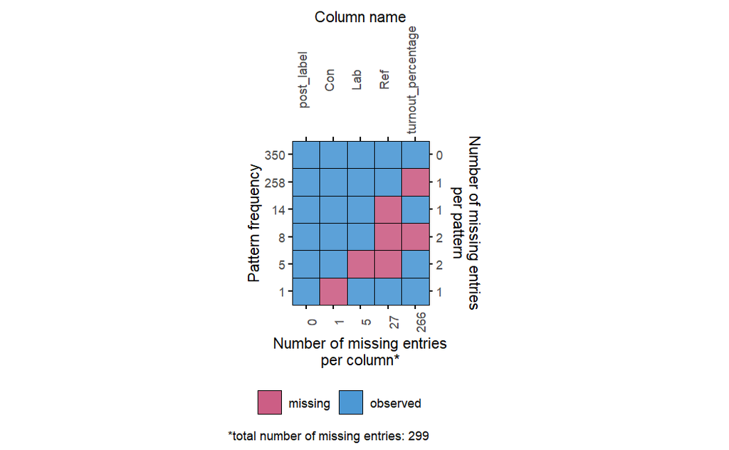

```r
plot_pattern(simp_dat, rotate = TRUE)
```

What percentage of missing data on turnout?

```r
(simp_dat$turnout_percentage |> is.na() |> mean() * 100) |> round(0)
```

```
[1] 42
```

Zap all the rows with any missing data (e.g., Reform didn’t stand a candidate or no turnout data is available).

```r
for_analy_counts <- na.omit(simp_dat)
```

Create another data frame with percentages, conditional on voting for one of these three parties.

```r
perc <- for_analy_counts |>
  pivot_longer(names_to = "Party",
               values_to = "Votes",
               cols = Ref:Con) |>
  group_by(post_label) |>
  mutate(Perc = 100 * Votes / sum(Votes))
perc
```

| post_label | turnout_percentage | Party | Votes | Perc |
| --- | --- | --- | --- | --- |
| Aberafan Maesteg | 49 | Ref | 7484 | 26.515500 |
| Aberafan Maesteg | 49 | Lab | 17838 | 63.199291 |
| Aberafan Maesteg | 49 | Con | 2903 | 10.285208 |
| Aberdeen North | 55 | Ref | 3781 | 16.853131 |
| Aberdeen North | 55 | Lab | 12773 | 56.933363 |
| Aberdeen North | 55 | Con | 5881 | 26.213506 |
| Aberdeenshire North and Moray East | 54 | Ref | 5562 | 25.338253 |
| Aberdeenshire North and Moray East | 54 | Lab | 3876 | 17.657510 |
| Aberdeenshire North and Moray East | 54 | Con | 12513 | 57.004237 |
| Aberdeen South | 60 | Ref | 3199 | 12.325653 |

[output cut: 990 more lines]

## Have a look

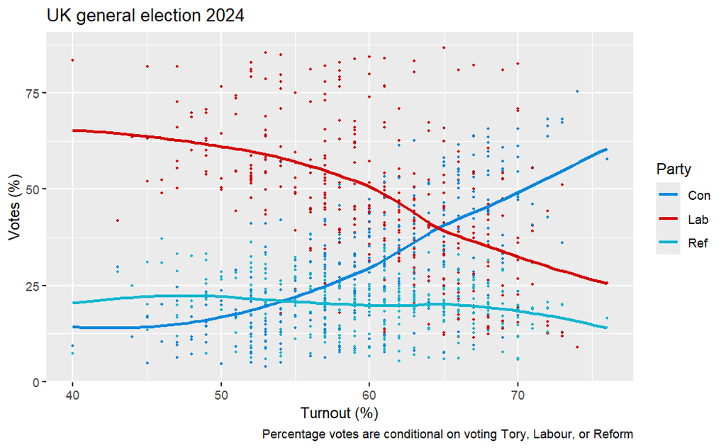

```r
perc |>
  ggplot(aes(turnout_percentage, Perc, colour = Party)) +
  geom_point(size = .7) +
  geom_smooth(se = FALSE,
              method = "loess",
              formula = y ~ x) +
  labs(
    x = "Turnout (%)",
    y = "Votes (%)",
    title = "UK general election 2024",
    caption = "Percentage votes are conditional on voting Tory, Labour, or Reform"
  ) +
  scale_color_manual(values = c("#0087dc", "#d50000", "#12b6cf"))
```

## Modelling

### Fit the models using the original counts

Now, onto the modelling. These use the generalized Wedderburn logit model.

```r
mod1_count <- colm(cbind(Con, Lab, Ref) ~ turnout_percentage, ref = 1, data = for_analy_counts)
mod2_count <- colm(cbind(Con, Lab, Ref) ~ turnout_percentage, ref = 2, data = for_analy_counts)
mod3_count <- colm(cbind(Con, Lab, Ref) ~ turnout_percentage, ref = 3, data = for_analy_counts)
```

```r
short_sum <- function(mod) {
  (mod |> summary())$Coefficients
}
```

```r
mod1_count |> short_sum()
```

```
   Lab / Con :
                   Estimate  St. err
(Intercept)         5.51500 0.347600
turnout_percentage -0.08419 0.005759

   Ref / Con :
                   Estimate  St. err
(Intercept)         3.28700 0.220400
turnout_percentage -0.06119 0.003653
```

```r
mod2_count |> short_sum()
```

```
   Con / Lab :
                   Estimate  St. err
(Intercept)        -5.51500 0.347600
turnout_percentage  0.08419 0.005759

   Ref / Lab :
                   Estimate  St. err
(Intercept)          -2.228 0.322500
turnout_percentage    0.023 0.005344
```

```r
mod3_count |> short_sum()
```

```
   Con / Ref :
                   Estimate  St. err
(Intercept)        -3.28700 0.220400
turnout_percentage  0.06119 0.003653

   Lab / Ref :
                   Estimate  St. err
(Intercept)           2.228 0.322500
turnout_percentage   -0.023 0.005344
```

I need to RTFM to work out how to interpret the coefficients; however, the estimates/SE for turnout are over 14 for the comparisons of Labour versus Conservative and Reform versus conservative. They are around 4 for Labour versus Reform.

### Try again with percentages

If I’ve understood correctly, then using the percentages as outcomes, rather than counts, should give the same results:

```r
for_analy_percs <- perc |>
  select(-Votes) |>
  pivot_wider(names_from = "Party",
              values_from = "Perc")
for_analy_percs
```

| post_label | turnout_percentage | Ref | Lab | Con |
| --- | --- | --- | --- | --- |
| Aberafan Maesteg | 49 | 26.515500 | 63.199291 | 10.285208 |
| Aberdeen North | 55 | 16.853131 | 56.933363 | 26.213506 |
| Aberdeenshire North and Moray East | 54 | 25.338253 | 17.657510 | 57.004237 |
| Aberdeen South | 60 | 12.325653 | 44.135779 | 43.538568 |
| Aldershot | 62 | 19.522054 | 46.995601 | 33.482345 |
| Ashfield | 58 | 53.507699 | 36.234202 | 10.258099 |
| Ashford | 62 | 26.078794 | 39.248058 | 34.673147 |
| Aylesbury | 63 | 18.595292 | 41.570649 | 39.834059 |
| Barking | 45 | 20.133105 | 63.154822 | 16.712073 |
| Barnsley North | 47 | 33.235873 | 57.275637 | 9.488489 |

[output cut: 340 more lines]

```r
mod1_perc <- colm(cbind(Con, Lab, Ref) ~ turnout_percentage, ref = 1, data = for_analy_percs)
mod2_perc <- colm(cbind(Con, Lab, Ref) ~ turnout_percentage, ref = 2, data = for_analy_percs)
mod3_perc <- colm(cbind(Con, Lab, Ref) ~ turnout_percentage, ref = 3, data = for_analy_percs)
```

Reference level Con:

```r
mod1_count |> short_sum()
```

```
   Lab / Con :
                   Estimate  St. err
(Intercept)         5.51500 0.347600
turnout_percentage -0.08419 0.005759

   Ref / Con :
                   Estimate  St. err
(Intercept)         3.28700 0.220400
turnout_percentage -0.06119 0.003653
```

```r
mod1_perc  |> short_sum()
```

```
   Lab / Con :
                   Estimate  St. err
(Intercept)         5.51500 0.347600
turnout_percentage -0.08419 0.005759

   Ref / Con :
                   Estimate  St. err
(Intercept)         3.28700 0.220400
turnout_percentage -0.06119 0.003653
```

Reference level Lab:

```r
mod2_count |> short_sum()
```

```
   Con / Lab :
                   Estimate  St. err
(Intercept)        -5.51500 0.347600
turnout_percentage  0.08419 0.005759

   Ref / Lab :
                   Estimate  St. err
(Intercept)          -2.228 0.322500
turnout_percentage    0.023 0.005344
```

```r
mod2_perc  |> short_sum()
```

```
   Con / Lab :
                   Estimate  St. err
(Intercept)        -5.51500 0.347600
turnout_percentage  0.08419 0.005759

   Ref / Lab :
                   Estimate  St. err
(Intercept)          -2.228 0.322500
turnout_percentage    0.023 0.005344
```

Reference level Reform:

```r
mod3_count |> short_sum()
```

```
   Con / Ref :
                   Estimate  St. err
(Intercept)        -3.28700 0.220400
turnout_percentage  0.06119 0.003653

   Lab / Ref :
                   Estimate  St. err
(Intercept)           2.228 0.322500
turnout_percentage   -0.023 0.005344
```

```r
mod3_perc  |> short_sum()
```

```
   Con / Ref :
                   Estimate  St. err
(Intercept)        -3.28700 0.220400
turnout_percentage  0.06119 0.003653

   Lab / Ref :
                   Estimate  St. err
(Intercept)           2.228 0.322500
turnout_percentage   -0.023 0.005344
```

And indeed they do.

## Multiple imputation – danger danger, going beyond the function manual…

Earlier we just zapped all missing data. Let’s bring back missingness in the turnouts and only drop rows where one or more of the three parties didn’t have a candidate.

```r
names(simp_dat)
```

```
[1] "post_label"         "turnout_percentage" "Ref"
[4] "Lab"                "Con"
```

```r
counts_with_miss <- simp_dat |>
  drop_na(Ref:Con)
```

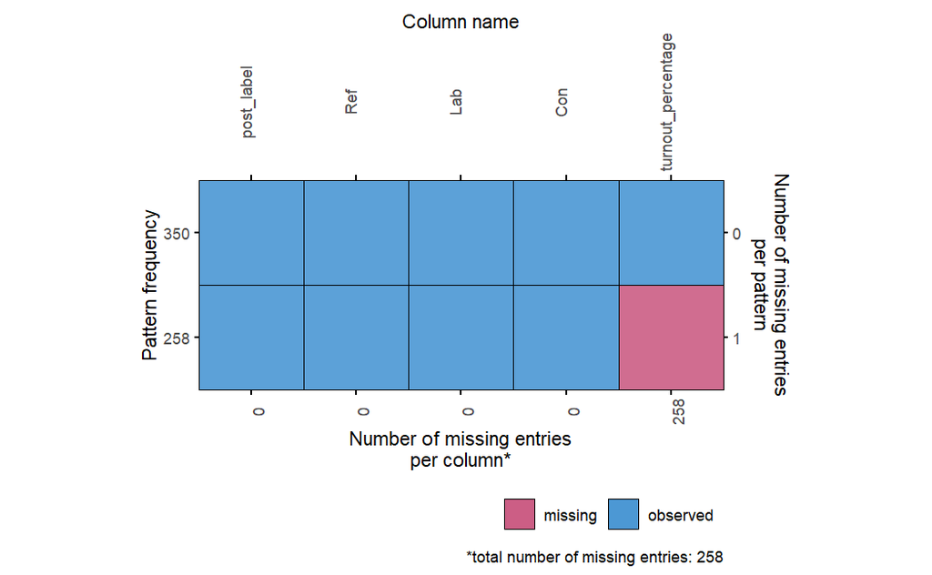

Impute 50 times with default settings.

```r
set.seed(1337)
imp <- mice(counts_with_miss, m = 50)
```

Fit (one of) the model(s) to each imputed dataset.

```r
mods <- with(imp, colm(cbind(Con, Lab, Ref) ~ turnout_percentage, ref = 1))
```

```r
get_params <- function(mod, comp = 1, pred) {
  the_coefs <- summary(mod)$Coefficients[[comp]]
  res <- the_coefs[pred, ]
  names(res) <- c("B", "SE")
  res
}
```

```r
get_params(mods$analyses[[1]], 1, "turnout_percentage")
```

```
        B        SE
-0.077550  0.004453
```

```r
the_coefs <- map(mods$analyses, \(m) get_params(m, 1, "turnout_percentage")) |> bind_rows()
the_coefs$N <- nrow(counts_with_miss)
the_coefs
```

| B | SE | N |
| --- | --- | --- |
| -0.07755 | 0.004453 | 608 |
| -0.07830 | 0.004348 | 608 |
| -0.08039 | 0.004389 | 608 |
| -0.07614 | 0.004318 | 608 |
| -0.07906 | 0.004415 | 608 |
| -0.07520 | 0.004341 | 608 |
| -0.07816 | 0.004293 | 608 |
| -0.07893 | 0.004342 | 608 |
| -0.07650 | 0.004273 | 608 |
| -0.07635 | 0.004521 | 608 |

[output cut: 40 more lines]

```r
pooled <- pool.scalar(the_coefs$B, the_coefs$SE^2, the_coefs$N)
res <- list(B = pooled$qbar, SE = sqrt(pooled$ubar))
res$t <- res$B / res$SE
res$df <- pooled$df[1]
res$p <- as.vector(pt(abs(res$t), df = res$df, lower.tail = FALSE) * 2)
res
```

```
$B
[1] -0.0771234

$SE
[1] 0.00436171

$t
[1] -17.68192

$df
[1] 330.3401

$p
[1] 1.054439e-49
```

```r
mod1_count |> short_sum()
```

```
   Lab / Con :
                   Estimate  St. err
(Intercept)         5.51500 0.347600
turnout_percentage -0.08419 0.005759

   Ref / Con :
                   Estimate  St. err
(Intercept)         3.28700 0.220400
turnout_percentage -0.06119 0.003653
```